# Question

En la gráfica se muestra la probabilidad de que la variable aleatoria $x$ tome valores en cada uno de tres intervalos en que se ha dividido la curva.

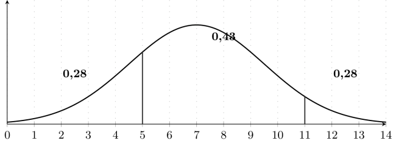

¿Cuál de las siguientes tablas representa la probabilidad de que la variable aleatoria $x$ tome los valores en el intervalo indicado?

- 1. | Intervalo | Probabilidad |
     | --- | --- |
     | $0 \le x \le 5$ | 0,43 |
     | $5 < x \le 11$ | 0,28 |
     | $11 < x \le 14$ | 0,28 |

- 2. | Intervalo | Probabilidad |
     | --- | --- |
     | $0 \le x \le 5$ | 0,28 |
     | $0 \le x \le 11$ | 0,43 |
     | $0 \le x \le 14$ | 0,28 |

- 3. | Intervalo | Probabilidad |
     | --- | --- |
     | $0 \le x \le 5$ | 0,28 |
     | $5 < x \le 11$ | 0,43 |
     | $11 < x \le 14$ | 0,28 |

- 4. | Intervalo | Probabilidad |
     | --- | --- |
     | $0 \le x \le 5$ | 0,28 |
     | $5 < x \le 11$ | 0,72 |
     | $11 < x \le 14$ | 1,00 |

# Solution

Para encontrar la tabla correcta, debemos extraer la información directamente del gráfico y compararla con las opciones proporcionadas.

**Paso 1: Analizar la información del gráfico.**

El gráfico está dividido en tres intervalos con sus respectivas probabilidades:

1. El primer intervalo va desde $x=0$ hasta $x=5$. La probabilidad en esta sección es **0,28**.
2. El segundo intervalo (central) va desde $x=5$ hasta $x=11$. La probabilidad en esta sección es **0,43**.
3. El tercer intervalo va desde $x=11$ hasta $x=14$. La probabilidad en esta sección es **0,28**.

**Paso 2: Construir la tabla esperada.**

Con la información anterior, la tabla correcta debe tener la siguiente estructura:

| Intervalo | Probabilidad |
| --- | --- |
| $0 \le x \le 5$ | 0,28 |
| $5 < x \le 11$ | 0,43 |
| $11 < x \le 14$ | 0,28 |

**Paso 3: Comparar con las opciones.**

Al revisar las tablas de las opciones, la única que coincide perfectamente con los datos extraídos del gráfico es la tabla correcta. Las otras tablas presentan errores comunes:

- **Error de probabilidad acumulada:** Una de las tablas muestra cómo la probabilidad se va sumando (0,28, 0,72, 1,00), lo cual es una interpretación incorrecta del gráfico.
- **Error de definición de intervalo:** Otra tabla usa intervalos acumulativos (ej: $0 \le x \le 11$), lo cual no corresponde a las secciones individuales mostradas.
- **Error de asignación:** Otra tabla intercambia los valores de probabilidad, asignando el valor central a los laterales y viceversa.

Por lo tanto, la respuesta correcta es la que representa fielmente los tres intervalos y sus probabilidades tal como se muestran en el gráfico.

- 1. | Intervalo | Probabilidad |
     | --- | --- |
     | $0 \le x \le 5$ | 0,43 |
     | $5 < x \le 11$ | 0,28 |
     | $11 < x \le 14$ | 0,28 |

     ```
     **Incorrecto.** Esta tabla no coincide con la información del gráfico. Revisa con atención los límites de los intervalos y los valores de probabilidad asignados a cada sección.
     ```

- 2. | Intervalo | Probabilidad |
     | --- | --- |
     | $0 \le x \le 5$ | 0,28 |
     | $0 \le x \le 11$ | 0,43 |
     | $0 \le x \le 14$ | 0,28 |

     ```
     **Incorrecto.** Esta tabla no coincide con la información del gráfico. Revisa con atención los límites de los intervalos y los valores de probabilidad asignados a cada sección.
     ```

- 3. | Intervalo | Probabilidad |
     | --- | --- |
     | $0 \le x \le 5$ | 0,28 |
     | $5 < x \le 11$ | 0,43 |
     | $11 < x \le 14$ | 0,28 |

     ```
     **Correcto.** Esta tabla representa exactamente los tres intervalos y sus probabilidades correspondientes como se muestra en el gráfico.
     ```

- 4. | Intervalo | Probabilidad |
     | --- | --- |
     | $0 \le x \le 5$ | 0,28 |
     | $5 < x \le 11$ | 0,72 |
     | $11 < x \le 14$ | 1,00 |

     ```
     **Incorrecto.** Esta tabla no coincide con la información del gráfico. Revisa con atención los límites de los intervalos y los valores de probabilidad asignados a cada sección.
     ```

# Meta-information

exname: probabilidad_distribucion_grafico_tabla extype: schoice exsolution: 0010 exshuffle: TRUE exsection: Estadística/Probabilidad/Interpretación de gráficos